# 5 Mitigation Strategies

- Show All Code
- Hide All Code
- View Source

```julia
projectdir = splitpath(pwd()) |>
    ss -> joinpath(ss[1:findall([s == "endogenous-macrodynamics-in-algorithmic-recourse" for s in ss])[1]]...)
cd(projectdir)
```

```julia
models = [
    :LogisticRegression,
    :FluxModel,
    :FluxEnsemble,
]
opt = Flux.Descent(0.01)
generators = Dict(
    :Generic=>GenericGenerator(opt = opt, decision_threshold=0.5),
    :Latent=>REVISEGenerator(opt = opt),
    :Generic_conservative=>GenericGenerator(opt = opt, decision_threshold=0.9),
    :Gravitational=>GravitationalGenerator(opt = opt),
    :ClapROAR=>ClapROARGenerator(opt = opt)
)
```

## 5.1 Mitigation Strategies

### 5.1.1 Running the Experiment

#### 5.1.1.1 Synthetic

```julia
max_obs = 1000
catalogue = load_synthetic(max_obs)
choices = [
    :linearly_separable,
    :overlapping,
    :circles,
    :moons,
]
data_sets = filter(p -> p[1] in choices, catalogue)
```

```julia
experiments = set_up_experiments(data_sets,models,generators)
```

```julia
n_evals = 5
n_rounds = 50
evaluate_every = Int(round(n_rounds/n_evals))
n_folds = 5
T = 100
using Serialization
results = run_experiments(
    experiments;
    save_path=output_path,evaluate_every=evaluate_every,n_rounds=n_rounds, n_folds=n_folds, T=T
)
Serialization.serialize(joinpath(output_path,"results_synthetic.jls"),results)
```

#### 5.1.1.2 Real World

```julia
models = [
    :LogisticRegression,
    :FluxModel,
    :FluxEnsemble,
]
opt = Flux.Descent(0.01)
generators = Dict(
    :Generic=>GenericGenerator(opt = opt, decision_threshold=0.5),
    :Latent=>REVISEGenerator(opt = opt),
    :Generic_conservative=>GenericGenerator(opt = opt, decision_threshold=0.9),
    :Gravitational=>GravitationalGenerator(opt = opt),
    :ClapROAR=>ClapROARGenerator(opt = opt)
)
```

```julia
max_obs = 2500
data_path = data_dir("real_world")
data_sets = load_real_world(max_obs)
choices = [
    :cal_housing,
    :credit_default,
    :gmsc,
]
data_sets = filter(p -> p[1] in choices, data_sets)
```

```julia
using CounterfactualExplanations.DataPreprocessing: unpack
bs = 500
function data_loader(data::CounterfactualData)
    X, y = unpack(data)
    data = Flux.DataLoader((X,y),batchsize=bs)
    return data
end
model_params = (batch_norm=false,n_hidden=64,n_layers=3,dropout=true,p_dropout=0.1)
```

```julia
experiments = set_up_experiments(
    data_sets,models,generators;
    pre_train_models=100, model_params=model_params,
    data_loader=data_loader
)
```

```julia
n_evals = 5
n_rounds = 50
evaluate_every = Int(round(n_rounds/n_evals))
n_folds = 5
n_samples = 10000
T = 100
generative_model_params = (epochs=250, latent_dim=8)
results = run_experiments(
    experiments;
    save_path=output_path,evaluate_every=evaluate_every,n_rounds=n_rounds, n_folds=n_folds, T=T, n_samples=n_samples,
    generative_model_params=generative_model_params
)
Serialization.serialize(joinpath(output_path,"results_real_world.jls"),results)
```

### 5.1.2 Results

```julia
data_names = [
    "California Housing",
    "Circles",
    "Credit Default",
    "GMSC",
    "Linearly Separable",
    "Moons",
    "Overlapping"
]
results = merge(EMAR.load_synthetic_mitigation(), EMAR.load_real_world_mitigation())
```

#### 5.1.2.1 Animated GIFs

```julia
using Images
line_charts = Dict()
errorbar_charts = Dict()
for (data_name, res) in results
    plt = plot_res(res)
    Images.save(joinpath(www_path, "line_chart_$(data_name).png"), plt)
    Images.save(joinpath(www_paper_path, "line_chart_$(data_name).png"), plt)
    line_charts[data_name] = plt
    plt = plot_res(res,maximum(res.output.n))
    Images.save(joinpath(www_path, "errorbar_chart_$(data_name).png"), plt)
    Images.save(joinpath(www_paper_path, "errorbar_chart_$(data_name).png"), plt)
    errorbar_charts[data_name] = plt
end
```

#### 5.1.2.2 Line Charts

The evolution of the evaluation metrics over the course of the experiment is shown for different datasets in Figure 5.1 to Figure 5.7.

[figure not shown]

Figure 5.1: Evolution of evaluation metrics over the course of the experiment. Data: California Housing.

[figure not shown]

Figure 5.2: Evolution of evaluation metrics over the course of the experiment. Data: Circles.

[figure not shown]

Figure 5.3: Evolution of evaluation metrics over the course of the experiment. Data: Credit Default.

[figure not shown]

Figure 5.4: Evolution of evaluation metrics over the course of the experiment. Data: GMSC.

[figure not shown]

Figure 5.5: Evolution of evaluation metrics over the course of the experiment. Data: Linearly Separable.

[figure not shown]

Figure 5.6: Evolution of evaluation metrics over the course of the experiment. Data: Moons.

[figure not shown]

Figure 5.7: Evolution of evaluation metrics over the course of the experiment. Data: Overlapping.

#### 5.1.2.3 Error Bar Charts

The evaluation metrics at the end of the experiment are shown for different datasets in Figure 5.8 to Figure 5.14.

[figure not shown]

Figure 5.8: Evaluation metrics at the end of the experiment. Data: California Housing.

[figure not shown]

Figure 5.9: Evaluation metrics at the end of the experiment. Data: Circles.

[figure not shown]

Figure 5.10: Evaluation metrics at the end of the experiment. Data: Credit Default.

[figure not shown]

Figure 5.11: Evaluation metrics at the end of the experiment. Data: GMSC.

[figure not shown]

Figure 5.12: Evaluation metrics at the end of the experiment. Data: Linearly Separable.

[figure not shown]

Figure 5.13: Evaluation metrics at the end of the experiment. Data: Moons.

[figure not shown]

Figure 5.14: Evaluation metrics at the end of the experiment. Data: Overlapping.

#### 5.1.2.4 Bootstrap

##### 5.1.2.4.1 Synthetic

```julia
n_bootstrap = 100
df = run_bootstrap(results, n_bootstrap; filename=joinpath(output_path,"bootstrap_synthetic.csv"))
```

Table 5.1 presents the tests for statistical significance of the estimated MMD metrics.

```julia
df = EMAR.aggregate_bs_mitigation_synthetic()
CSV.write(joinpath(www_path, "bootstrap_synthetic.csv"), df)
CSV.write(joinpath(www_paper_path, "bootstrap_synthetic.csv"), df)
EMAR.tabulate_bs(df, Val(:html))
```

Table 5.1: Tests for statistical significance of the estimated MMD metrics using mitigation strategies. We have highlighted p-values smaller than the significance level $\alpha=0.05$ in bold. Data: Synthetic.

| Metric | Data | Generator | Model | p-value |
| --- | --- | --- | --- | --- |
| MMD | Circles | ClapROAR | Deep Ensemble | 0.984 |
| MMD | Circles | ClapROAR | Linear | 1.0 |
| MMD | Circles | ClapROAR | MLP | 0.992 |
| MMD | Circles | Generic (γ=0.5) | Deep Ensemble | 0.99 |
| MMD | Circles | Generic (γ=0.5) | Linear | 1.0 |
| MMD | Circles | Generic (γ=0.5) | MLP | 0.994 |
| MMD | Circles | Generic (γ=0.9) | Deep Ensemble | 0.996 |
| MMD | Circles | Generic (γ=0.9) | Linear | 1.0 |
| MMD | Circles | Generic (γ=0.9) | MLP | 0.992 |
| MMD | Circles | Gravitational | Deep Ensemble | 0.998 |
| MMD | Circles | Gravitational | Linear | 1.0 |
| MMD | Circles | Gravitational | MLP | 0.998 |
| MMD | Circles | Latent | Deep Ensemble | 1.0 |
| MMD | Circles | Latent | Linear | 1.0 |
| MMD | Circles | Latent | MLP | 1.0 |
| MMD | Linearly Separable | ClapROAR | Deep Ensemble | 0.0 |
| MMD | Linearly Separable | ClapROAR | Linear | 0.0 |
| MMD | Linearly Separable | ClapROAR | MLP | 0.0 |
| MMD | Linearly Separable | Generic (γ=0.5) | Deep Ensemble | 0.0 |
| MMD | Linearly Separable | Generic (γ=0.5) | Linear | 0.0 |
| MMD | Linearly Separable | Generic (γ=0.5) | MLP | 0.0 |
| MMD | Linearly Separable | Generic (γ=0.9) | Deep Ensemble | 0.0 |
| MMD | Linearly Separable | Generic (γ=0.9) | Linear | 0.0 |
| MMD | Linearly Separable | Generic (γ=0.9) | MLP | 0.0 |
| MMD | Linearly Separable | Gravitational | Deep Ensemble | 0.05 |
| MMD | Linearly Separable | Gravitational | Linear | 0.092 |
| MMD | Linearly Separable | Gravitational | MLP | 0.078 |
| MMD | Linearly Separable | Latent | Deep Ensemble | 0.724 |
| MMD | Linearly Separable | Latent | Linear | 0.75 |
| MMD | Linearly Separable | Latent | MLP | 0.742 |

[output cut: 150 more lines]

##### 5.1.2.4.2 Real-World

Table 5.2 presents the tests for statistical significance of the estimated MMD metrics.

```julia
df = EMAR.aggregate_bs_mitigation_real_world()
CSV.write(joinpath(www_path, "bootstrap_real_world.csv"), df)
CSV.write(joinpath(www_paper_path, "bootstrap_real_world.csv"), df)
EMAR.tabulate_bs(df, Val(:html))
```

Table 5.2: Tests for statistical significance of the estimated MMD metrics using mitigation strategies. We have highlighted p-values smaller than the significance level $\alpha=0.05$ in bold. Data: Real-World.

| Metric | Data | Generator | Model | p-value |
| --- | --- | --- | --- | --- |
| MMD | Cal Housing | ClapROAR | Deep Ensemble | 0.0 |
| MMD | Cal Housing | ClapROAR | Linear | 0.0 |
| MMD | Cal Housing | ClapROAR | MLP | 0.0 |
| MMD | Cal Housing | Generic (γ=0.5) | Deep Ensemble | 0.0 |
| MMD | Cal Housing | Generic (γ=0.5) | Linear | 0.0 |
| MMD | Cal Housing | Generic (γ=0.5) | MLP | 0.0 |
| MMD | Cal Housing | Generic (γ=0.9) | Deep Ensemble | 0.0 |
| MMD | Cal Housing | Generic (γ=0.9) | Linear | 0.0 |
| MMD | Cal Housing | Generic (γ=0.9) | MLP | 0.0 |
| MMD | Cal Housing | Gravitational | Deep Ensemble | 0.0 |
| MMD | Cal Housing | Gravitational | Linear | 0.0 |
| MMD | Cal Housing | Gravitational | MLP | 0.0 |
| MMD | Cal Housing | Latent | Deep Ensemble | 0.0 |
| MMD | Cal Housing | Latent | Linear | 0.0 |
| MMD | Cal Housing | Latent | MLP | 0.0 |
| MMD | Credit Default | ClapROAR | Deep Ensemble | 1.0 |
| MMD | Credit Default | ClapROAR | Linear | 1.0 |
| MMD | Credit Default | ClapROAR | MLP | 1.0 |
| MMD | Credit Default | Generic (γ=0.5) | Deep Ensemble | 1.0 |
| MMD | Credit Default | Generic (γ=0.5) | Linear | 1.0 |
| MMD | Credit Default | Generic (γ=0.5) | MLP | 1.0 |
| MMD | Credit Default | Generic (γ=0.9) | Deep Ensemble | 1.0 |
| MMD | Credit Default | Generic (γ=0.9) | Linear | 1.0 |
| MMD | Credit Default | Generic (γ=0.9) | MLP | 1.0 |
| MMD | Credit Default | Gravitational | Deep Ensemble | 0.0 |
| MMD | Credit Default | Gravitational | Linear | 0.0 |
| MMD | Credit Default | Gravitational | MLP | 0.0 |
| MMD | Credit Default | Latent | Deep Ensemble | 0.0 |
| MMD | Credit Default | Latent | Linear | 0.8 |
| MMD | Credit Default | Latent | MLP | 0.0 |

[output cut: 105 more lines]

#### 5.1.2.5 Chart in paper (Figure 6)

Figure 5.15 shows the chart that went into the paper.

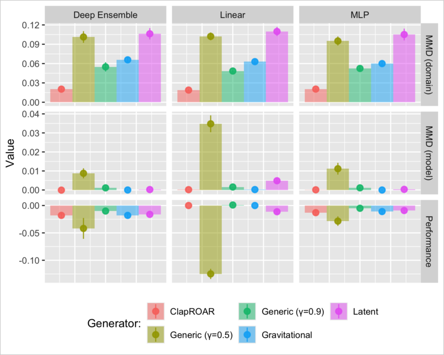

Figure 5.15: Chart in paper

```julia
Images.load(joinpath(www_artifact_path,"paper_synthetic_results.png"))
```

#### 5.1.2.6 Chart in paper (Figure 8)

```julia
results = EMAR.load_real_world_mitigation()
```

Figure 5.16 shows the chart that went into the paper.

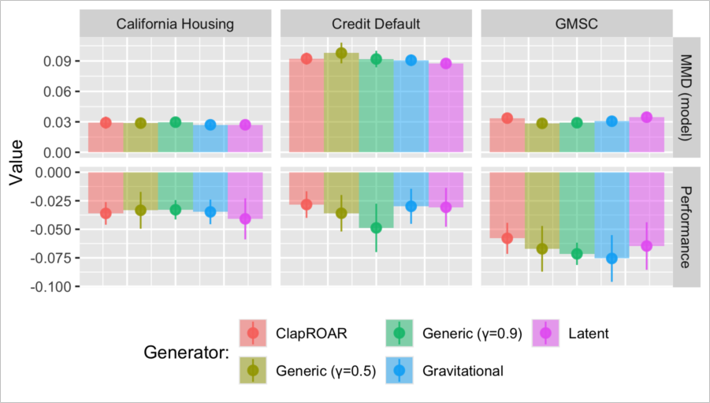

Figure 5.16: Chart in paper

```julia
Images.load(joinpath(www_artifact_path,"paper_real_world_results.png"))
```

## 5.2 Mitigation and Latent Space Search

For the synthetic datasets, we investigate the effect of combining latent space search with the mitigation strategies.

### 5.2.1 Running the Experiment

```julia
generators = Dict(
    :Latent=>GenericGenerator(opt = opt, decision_threshold=0.5),
    :Latent_conservative=>GenericGenerator(opt = opt, decision_threshold=0.9),
    :Gravitational=>GravitationalGenerator(opt = opt),
    :ClapROAR=>ClapROARGenerator(opt = opt)
)
```

```julia
experiments = set_up_experiments(data_sets,models,generators)
```

```julia
n_evals = 5
n_rounds = 50
evaluate_every = Int(round(n_rounds/n_evals))
n_folds = 5
T = 100
using Serialization
results = run_experiments(
    experiments;
    save_path=output_path, evaluate_every=evaluate_every, n_rounds=n_rounds, n_folds=n_folds, T=T,
    latent_space = true
)
Serialization.serialize(joinpath(output_path,"results_synthetic_latent.jls"),results)
```

```julia
data_names = ["Circles", "Linearly Separable", "Moons", "Overlapping"]
results = EMAR.load_synthetic_mitigation_latent()
```

```julia
using Images
line_charts = Dict()
errorbar_charts = Dict()
for (data_name, res) in results
    plt = plot_res(res)
    Images.save(joinpath(www_path, "line_chart_latent_$(data_name).png"), plt)
    Images.save(joinpath(www_paper_path, "line_chart_latent_$(data_name).png"), plt)
    line_charts[data_name] = plt
    plt = plot_res(res,maximum(res.output.n))
    Images.save(joinpath(www_path, "errorbar_chart_latent_$(data_name).png"), plt)
    Images.save(joinpath(www_paper_path, "errorbar_chart_latent_$(data_name).png"), plt)
    errorbar_charts[data_name] = plt
end
```

### 5.2.2 Results

#### 5.2.2.1 Line Charts

The evolution of the evaluation metrics over the course of the experiment is shown for different datasets in Figure 5.17 to Figure 5.20.

[figure not shown]

Figure 5.17: Evolution of evaluation metrics over the course of the experiment. Data: Circles.

[figure not shown]

Figure 5.18: Evolution of evaluation metrics over the course of the experiment. Data: Linearly Separable.

[figure not shown]

Figure 5.19: Evolution of evaluation metrics over the course of the experiment. Data: Moons.

[figure not shown]

Figure 5.20: Evolution of evaluation metrics over the course of the experiment. Data: Overlapping.

#### 5.2.2.2 Error Bar Charts

The evaluation metrics at the end of the experiment are shown for different datasets in Figure 5.21 to Figure 5.24.

[figure not shown]

Figure 5.21: Evaluation metrics at the end of the experiment. Data: Circles.

[figure not shown]

Figure 5.22: Evaluation metrics at the end of the experiment. Data: Linearly Separable.

[figure not shown]

Figure 5.23: Evaluation metrics at the end of the experiment. Data: Moons.

[figure not shown]

Figure 5.24: Evaluation metrics at the end of the experiment. Data: Overlapping.

#### 5.2.2.3 Bootstrap

Table 5.3 presents the tests for statistical significance of the estimated MMD metrics.

```julia
n_bootstrap = 100
df = run_bootstrap(results, n_bootstrap; filename=joinpath(output_path,"bootstrap_latent.csv"))
```

Table 5.3: Tests for statistical significance of the estimated MMD metrics using mitigation strategies with Latent Space Search. We have highlighted p-values smaller than the significance level $\alpha=0.05$ in bold.

| Metric | Data | Generator | Model | p-value |
| --- | --- | --- | --- | --- |
| MMD | Circles | ClapROAR | Deep Ensemble | 1.0 |
| MMD | Circles | ClapROAR | Linear | 0.994 |
| MMD | Circles | ClapROAR | MLP | 1.0 |
| MMD | Circles | Gravitational | Deep Ensemble | 0.998 |
| MMD | Circles | Gravitational | Linear | 1.0 |
| MMD | Circles | Gravitational | MLP | 1.0 |
| MMD | Circles | Latent (γ=0.5) | Deep Ensemble | 1.0 |
| MMD | Circles | Latent (γ=0.5) | Linear | 0.996 |
| MMD | Circles | Latent (γ=0.5) | MLP | 1.0 |
| MMD | Circles | Latent (γ=0.9) | Deep Ensemble | 1.0 |
| MMD | Circles | Latent (γ=0.9) | Linear | 0.996 |
| MMD | Circles | Latent (γ=0.9) | MLP | 1.0 |
| MMD | Linearly Separable | ClapROAR | Deep Ensemble | 0.334 |
| MMD | Linearly Separable | ClapROAR | Linear | 0.866 |
| MMD | Linearly Separable | ClapROAR | MLP | 0.168 |
| MMD | Linearly Separable | Gravitational | Deep Ensemble | 0.38 |
| MMD | Linearly Separable | Gravitational | Linear | 0.82 |
| MMD | Linearly Separable | Gravitational | MLP | 0.0 |
| MMD | Linearly Separable | Latent (γ=0.5) | Deep Ensemble | 0.0 |
| MMD | Linearly Separable | Latent (γ=0.5) | Linear | 0.892 |
| MMD | Linearly Separable | Latent (γ=0.5) | MLP | 0.126 |
| MMD | Linearly Separable | Latent (γ=0.9) | Deep Ensemble | 0.0 |
| MMD | Linearly Separable | Latent (γ=0.9) | Linear | 0.896 |
| MMD | Linearly Separable | Latent (γ=0.9) | MLP | 0.0 |
| MMD | Moons | ClapROAR | Deep Ensemble | 0.0 |
| MMD | Moons | ClapROAR | Linear | 0.0 |
| MMD | Moons | ClapROAR | MLP | 0.0 |
| MMD | Moons | Gravitational | Deep Ensemble | 0.0 |
| MMD | Moons | Gravitational | Linear | 0.0 |
| MMD | Moons | Gravitational | MLP | 0.0 |

[output cut: 114 more lines]

#### 5.2.2.4 Chart in paper (Figure 7)

Figure 5.25 shows the chart that went into the paper.

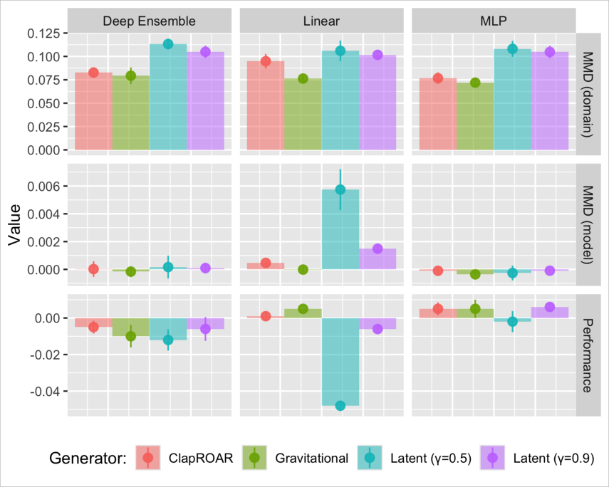

Figure 5.25: Chart in paper

```julia
Images.load(joinpath(www_artifact_path,"paper_synthetic_latent_results.png"))
```